# Capstone Milestone Report

Pieter van der Veere

20 October 2018

## Introduction

This report shall outline the progress made on the Coursera Data Science Capstone project. The report will comprise of three part: acquiring and cleaning the data, presenting a visually representation of the most common words, demonstrating how cut-offs can be calculated for your n-gram models.

## Data collection

The following code extracts a subset of the lines from the pre-downloaded corpus. Due to the way the way-back machine providing the corpus was set up, it was not possible to download it through code. A subset of lines was taken because only limited processing power was avalaible at the time of writing.

```r
library(here)
set.seed(2018091413)
lines <- sample(77259, 40000)
###77259 because it's the amount of lines in the news file

#Opening files and sampling lines
con <- file(here("data/en_US", "en_US.twitter.txt"), "r")
twitDataSmall <- readLines(con, 1e5)
twitDataSmall <- twitDataSmall[lines]
close(con)

con <- file(here("data/en_US", "en_US.blogs.txt"), "r")
blogDataSmall <- readLines(con, 1e5)
blogDataSmall <- blogDataSmall[lines]
close(con)

con <- file(here("data/en_US", "en_US.news.txt"), "r")
newsDataSmall <- readLines(con)
newsDataSmall <- newsDataSmall[lines]
close(con)

#Making new dataset
dataSmall <- c(twitDataSmall, blogDataSmall, newsDataSmall)
```

## Cleaning the data

The following code cleans up the dataset. It removes bad word, special characters often seen in tweets, removes digits and punctuation, and additional whitespaces created by any of the previous steps. While it is possible to stem the words and remove common words I choose not to do this as it makes the output of any prediction model unrepresentative of real text.

```r
library(tm)
library(here)
badWords <- readLines(here("data/en_US", "bad-words.txt"))
##Getting rid of offensive words
badWords <- paste("\\b", badWords, "\\b", sep="", collapse = "|")
badLines <- grep(badWords, dataSmall)

if (class(badLines) == "integer") {
    dataSmall <- dataSmall[-badLines]
}

##pre-processecing data
ascCode <- 128:255 ###ASCII for special characters
ascCode <- as.raw(ascCode)
specialChar <- sapply(ascCode, rawToChar)
specialChar <- paste(specialChar, sep = "", collapse= "|")

dataSmallPreProc <- tolower(dataSmall)
dataSmallPreProc <- gsub(pattern = specialChar,
                         replacement = "", x = dataSmallPreProc)
dataSmallPreProc <- gsub(pattern = "[[:digit:]]|[[:punct:]]|",
                         replacement = "", x = dataSmallPreProc)
dataSmallPreProc <- stripWhitespace(dataSmallPreProc)
```

## Frequency counting words

The following code creates a list of the 20 most common words.

```r
library(tm)
ctrl <- list(language = "en_US", removePunctuation = T,
    removeNumbers = T)
termFreq <- termFreq(dataSmallPreProc, control = ctrl)
termFreq <- sort(termFreq, decreasing = T)
view <- as.data.frame(termFreq)
head(view, 20)
```

```
##      termFreq
## the    173497
## and     88945
## that    37222
## for     36036
## you     25449
## with    25338
## was     23137
## this    18467
## have    17905
## but     16639
## are     16508
## from    13808
## not     13794
## said    11683
## its     11565
## his     11427
## they    11407
## will    10815
## all     10664
## one      9991
```

## Visually representation of most common words

These words can then be visually represented. The graph showed that only a small amount of words are very frequent. This implies that not all words, or n-grams, would have to be included to created a fairly accurate model.

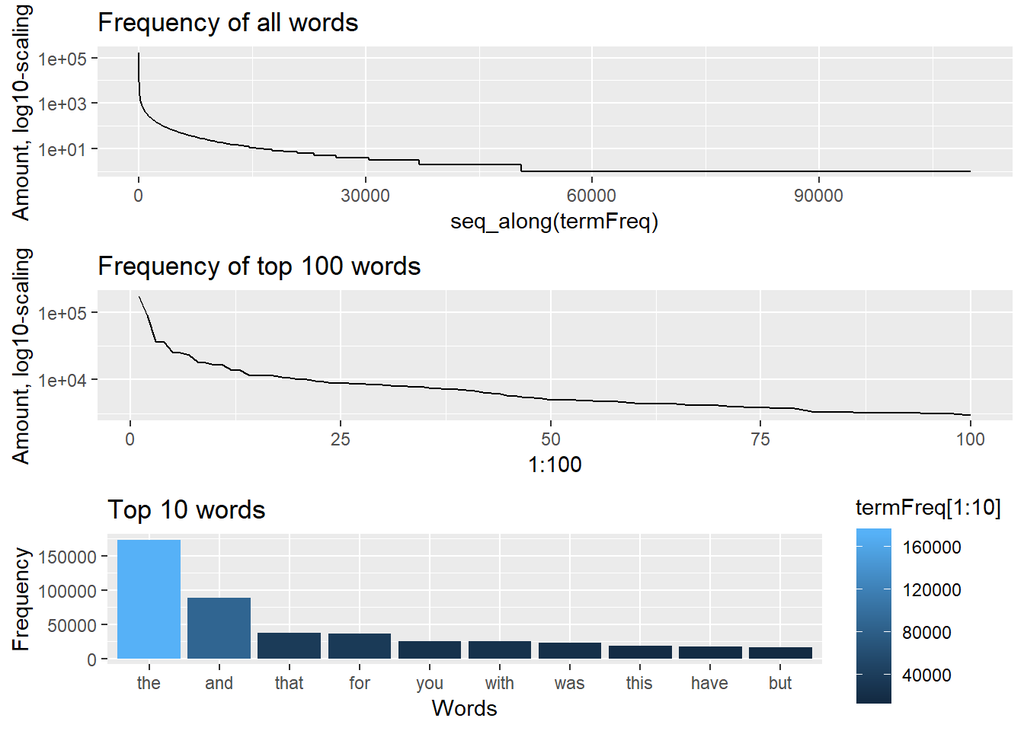

```r
library(ggplot2)
library(gridExtra)

qFreqHist1 <- ggplot(as.data.frame(termFreq),
    aes(y= termFreq, x= seq_along(termFreq)))
qFreqHist1 <- qFreqHist1 + geom_line() +
    scale_y_log10(name = "Amount, log10-scaling")
qFreqHist1 <- qFreqHist1 + labs(title= "Frequency of all words")

qFreqHist2 <- ggplot(as.data.frame(termFreq[1:100]),
                                   aes(y= termFreq[1:100], x= 1:100))
qFreqHist2 <- qFreqHist2 + geom_line() +
    scale_y_log10(name = "Amount, log10-scaling")
qFreqHist2 <- qFreqHist2 + labs(title= "Frequency of top 100 words")

rownm <- names(termFreq)[1:10]
rownm <- factor(rownm, levels = rownm[order(termFreq, decreasing= T)])

qFreqHist3 <- ggplot(as.data.frame(termFreq[1:10]),
        aes(x = rownm, y= termFreq[1:10]))
qFreqHist3 <- qFreqHist3 + geom_col(aes(fill = termFreq[1:10]))
qFreqHist3 <- qFreqHist3 + labs(title= "Top 10 words",
        x= "Words", y = "Frequency")

library(gridExtra)
grid.arrange(qFreqHist1, qFreqHist2, qFreqHist3)
```

## Cut-off point calculations

To demonstrate the amount of words needed to cover 50% of all words used, the following algorithm was written. While the example is not necessairly informative as no one word n-grams will be used in a model. It can be used for any n-gram frequency model with only minor changes, being of definite use in slimming down the model.

```r
tWordUse <- sum(termFreq, na.rm =T)
goal <- .5
cover <- 0
cutOff <- 0
tCover <- 0

while(cover < goal) {
    cutOff <- cutOff + 1
    tCover <- tCover + termFreq[cutOff]
    cover <- tCover/tWordUse
    if (cover >= goal) {
        print(cutOff)
    }
}
```

```
## [1] 330
```

```r
tWord <-length(termFreq)
```

The amount of words need to cover 50% of total word use is 330, while the total amount of words is 110068.